# Baseball Hall of Fame Prediction

Fatane Telikani

# Introduction

Baseball Hall of Fame induction is a binary classification problem because the outcome is either “Yes” or “No.” Historical player statistics can be used to identify factors associated with Hall of Fame induction and to estimate the probability that a player will be inducted.

This project builds a logistic regression model using career statistics from Major League Baseball players. The final model is then used to predict the Hall of Fame status of players in the 2026 dataset.

# Objective

The goal of this project is to develop a logistic regression model that predicts whether a baseball player will be inducted into the Hall of Fame based on career performance statistics.

The analysis includes data exploration, feature selection, model development, model evaluation, and prediction for the 2026 players.

# Dataset

This project uses two datasets.

The training dataset contains **644** Major League Baseball players who received at least one Hall of Fame vote. It includes career performance statistics and a response variable indicating whether each player was inducted into the Hall of Fame.

The prediction dataset contains **12** players from the 2026 Hall of Fame ballot. It includes the same predictor variables but does not include the Hall of Fame outcome. The trained model uses this dataset to predict each player’s probability of Hall of Fame induction.

# Exploratory Data Analysis

## Dataset Overview

This section explores the dataset before building the logistic regression model. The first step is to examine the variables, data types, and overall distribution of the data.

```r
baseballHOF <- read.csv("~/Desktop/courses/Projects/project1/baseballHOF.csv")
dim(baseballHOF)
```

```
## [1] 644  22
```

```r
str(baseballHOF)
```

```
## 'data.frame':    644 obs. of  22 variables:
##  $ Name     : chr  "Aaron Boone" "Adam Dunn" "Adam Jones" "Adrian Beltre" ...
##  $ HoF      : chr  "No" "No" "No" "Yes" ...
##  $ Yrs      : int  12 14 14 21 15 19 14 22 18 20 ...
##  $ WAR      : num  13.5 17.4 32.6 93.5 43.5 23.8 43.2 92.8 43.7 68.8 ...
##  $ WAR7     : num  15.2 17.7 25.7 48.7 34.6 18.1 33.1 48.8 28.1 45.8 ...
##  $ JAWS     : num  14.4 17.6 29.2 71.1 39.1 20.9 38.1 70.8 35.9 57.3 ...
##  $ Jpos     : num  56.1 53.5 58 56.1 53.4 44.3 55.4 56 58 53.5 ...
##  $ JAWSratio: num  25.7 32.9 50.3 126.7 73.2 ...
##  $ G        : int  1152 2001 1823 2933 1929 2059 1828 2834 2368 2215 ...
##  $ AB       : int  3871 6883 7009 11068 7139 7290 7219 10116 9049 8759 ...
##  $ R        : int  519 1097 963 1524 997 807 1064 1622 1189 1507 ...
##  $ H        : int  1071 1631 1939 3126 2050 2043 2089 3007 2743 2927 ...
##  $ HR       : int  126 462 282 477 317 188 126 399 219 307 ...
##  $ RBI      : int  555 1168 945 1707 1202 909 757 1582 1326 1828 ...
##  $ SB       : int  107 63 97 121 6 15 59 137 84 88 ...
##  $ BB       : int  303 1317 340 848 782 308 430 1277 535 615 ...
##  $ BA       : num  0.263 0.237 0.277 0.286 0.287 0.28 0.289 0.297 0.303 0.334 ...
##  $ OBP      : num  0.326 0.364 0.317 0.339 0.358 0.319 0.333 0.376 0.344 0.38 ...
##  $ SLG      : num  0.425 0.49 0.454 0.48 0.485 0.42 0.411 0.48 0.451 0.535 ...
##  $ OPS      : num  0.751 0.854 0.711 0.819 0.843 0.739 0.744 0.855 0.795 0.915 ...
##  $ OPSadj   : int  94 124 106 116 129 94 98 134 121 133 ...
##  $ position : chr  "3B" "LF" "CF" "3B" ...
```

```r
summary(baseballHOF)
```

```
##         Name            HoF           Yrs             WAR
##  Length   :644   Length   :644   Min.   : 4.00   Min.   : -5.30
##  N.unique :644   N.unique :  2   1st Qu.:13.00   1st Qu.: 23.25
##  N.blank  :  0   N.blank  :  0   Median :16.00   Median : 37.15
##  Min.nchar:  7   Min.nchar:  2   Mean   :15.77   Mean   : 40.27
##  Max.nchar: 20   Max.nchar:  3   3rd Qu.:18.00   3rd Qu.: 52.62
##                                  Max.   :27.00   Max.   :162.80
##       WAR7            JAWS             Jpos        JAWSratio
##  Min.   : 0.00   Min.   : -2.00   Min.   :44.3   Min.   : -4.515
##  1st Qu.:20.70   1st Qu.: 22.05   1st Qu.:53.4   1st Qu.: 40.547
##  Median :28.50   Median : 33.10   Median :55.4   Median : 60.487
##  Mean   :29.11   Mean   : 34.69   Mean   :54.1   Mean   : 63.846
##  3rd Qu.:37.12   3rd Qu.: 44.52   3rd Qu.:56.1   3rd Qu.: 81.275
##  Max.   :84.70   Max.   :123.40   Max.   :58.0   Max.   :220.357
##        G              AB              R                H              HR
##  Min.   :  67   Min.   :  186   Min.   :  25.0   Min.   :  54   Min.   :  1.0
##  1st Qu.:1456   1st Qu.: 5056   1st Qu.: 700.5   1st Qu.:1414   1st Qu.: 51.0
##  Median :1816   Median : 6460   Median : 936.5   Median :1809   Median :131.5
##  Mean   :1805   Mean   : 6457   Mean   : 967.1   Mean   :1843   Mean   :175.7
##  3rd Qu.:2152   3rd Qu.: 7803   3rd Qu.:1196.2   3rd Qu.:2250   3rd Qu.:267.2
##  Max.   :3562   Max.   :14053   Max.   :2295.0   Max.   :4256   Max.   :762.0
##       RBI               SB               BB               BA
##  Min.   :  24.0   Min.   :   2.0   Min.   :   7.0   Min.   :0.208
##  1st Qu.: 592.8   1st Qu.:  40.0   1st Qu.: 437.8   1st Qu.:0.267
##  Median : 884.0   Median :  89.5   Median : 640.0   Median :0.282
##  Mean   : 910.7   Mean   : 150.1   Mean   : 689.9   Mean   :0.283
##  3rd Qu.:1179.2   3rd Qu.: 201.0   3rd Qu.: 874.0   3rd Qu.:0.297
##  Max.   :2297.0   Max.   :1406.0   Max.   :2558.0   Max.   :0.366
##       OBP              SLG              OPS             OPSadj
##  Min.   :0.2540   Min.   :0.2560   Min.   :0.5290   Min.   : 22.0
##  1st Qu.:0.3320   1st Qu.:0.3830   1st Qu.:0.7250   1st Qu.: 99.0
##  Median :0.3540   Median :0.4310   Median :0.7880   Median :113.5
##  Mean   :0.3534   Mean   :0.4295   Mean   :0.7827   Mean   :113.0
##  3rd Qu.:0.3723   3rd Qu.:0.4740   3rd Qu.:0.8375   3rd Qu.:126.0
##  Max.   :0.4820   Max.   :0.6900   Max.   :1.1640   Max.   :206.0
##       position
##  Length   :644
##  N.unique :  8
##  N.blank  :  0
##  Min.nchar:  1
##  Max.nchar:  2
##
```

## Standard Deviation of Numeric Variables

The standard deviation of each numeric variable is calculated to measure how much the values vary across players.

```r
sapply(baseballHOF, function(x)
  if(is.numeric(x)) sd(x, na.rm = TRUE) else NA)
```

```
##         Name          HoF          Yrs          WAR         WAR7         JAWS
##           NA           NA 3.585318e+00 2.559984e+01 1.316518e+01 1.917399e+01
##         Jpos    JAWSratio            G           AB            R            H
## 4.023937e+00 3.458425e+01 5.261350e+02 2.066071e+03 3.964577e+02 6.490540e+02
##           HR          RBI           SB           BB           BA          OBP
## 1.498513e+02 4.060295e+02 1.632660e+02 3.554362e+02 2.361958e-02 3.176972e-02
##          SLG          OPS       OPSadj     position
## 6.527569e-02 8.905685e-02 2.178443e+01           NA
```

## Distribution of Selected Variables

Histograms are used to examine the distribution of several important player statistics.

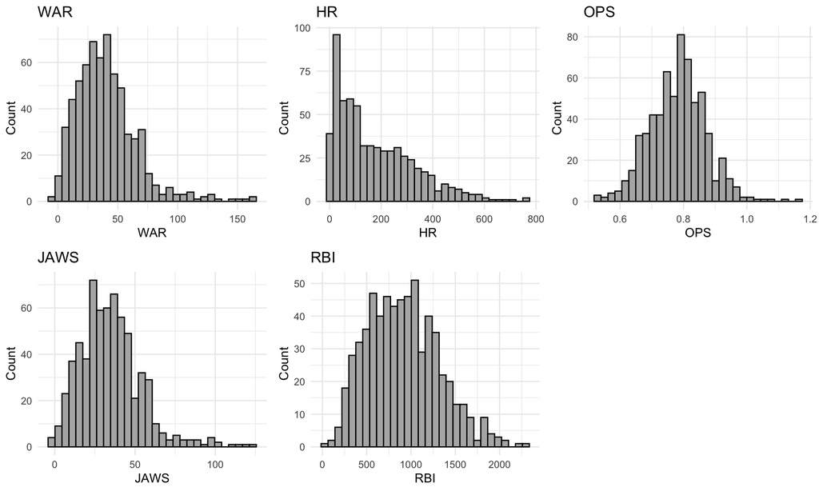

```r
library(ggplot2)
library(gridExtra)

quantitative_vars <- c("WAR", "HR", "OPS", "JAWS", "RBI")

histograms <- lapply(quantitative_vars, function(var) {
  ggplot(baseballHOF, aes(x = .data[[var]])) +
    geom_histogram(bins = 30, fill = "grey70", color = "black") +
    labs(
      title = var,
      x = var,
      y = "Count"
    ) +
    theme_minimal()
})

grid.arrange(grobs = histograms, ncol = 3)
```

Most variables are right-skewed, indicating that a small number of players have exceptionally high career statistics.

## Detecting Outliers

Boxplots are used to identify potential outliers in the selected variables.

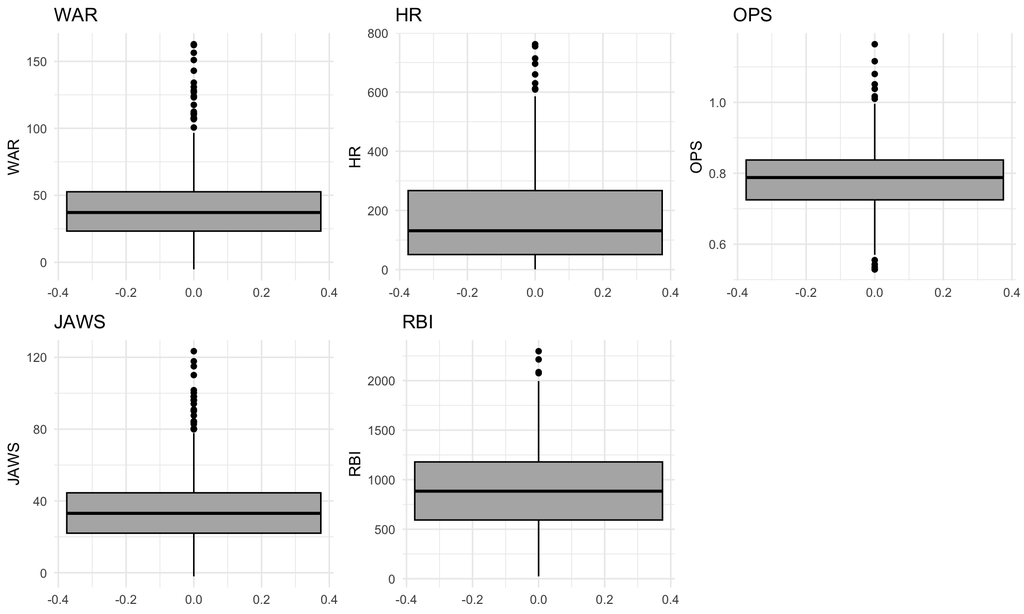

```r
library(ggplot2)
library(gridExtra)

quantitative_vars <- c("WAR", "HR", "OPS", "JAWS", "RBI")

boxplots <- lapply(quantitative_vars, function(var) {
  ggplot(baseballHOF, aes(y = .data[[var]])) +
    geom_boxplot(fill = "grey70", color = "black") +
    labs(
      title = var,
      y = var,
      x = NULL
    ) +
    theme_minimal()
})

grid.arrange(grobs = boxplots, ncol = 3)
```

Several variables contain extreme values. These observations represent exceptional player performance and are expected in professional sports data.

## Categorical Variables

The categorical variables are summarized using frequency tables and bar charts. These summaries show the distribution of player positions and Hall of Fame induction status.

```r
# Frequency table for Position
table(baseballHOF$position)
```

```
##
## 1B 2B 3B  C CF LF RF SS
## 91 68 75 82 77 81 89 81
```

```r
# Frequency table for Hall of Fame status
table(baseballHOF$HoF)
```

```
##
##  No Yes
## 472 172
```

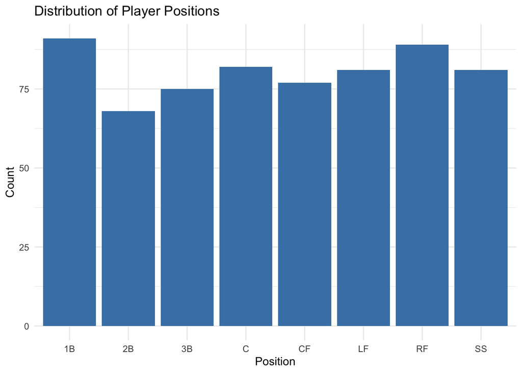

```r
# Bar Plot: Player Position
library(ggplot2)

ggplot(baseballHOF, aes(x = position)) +
  geom_bar(fill = "steelblue") +
  labs(
    title = "Distribution of Player Positions",
    x = "Position",
    y = "Count"
  ) +
  theme_minimal()
```

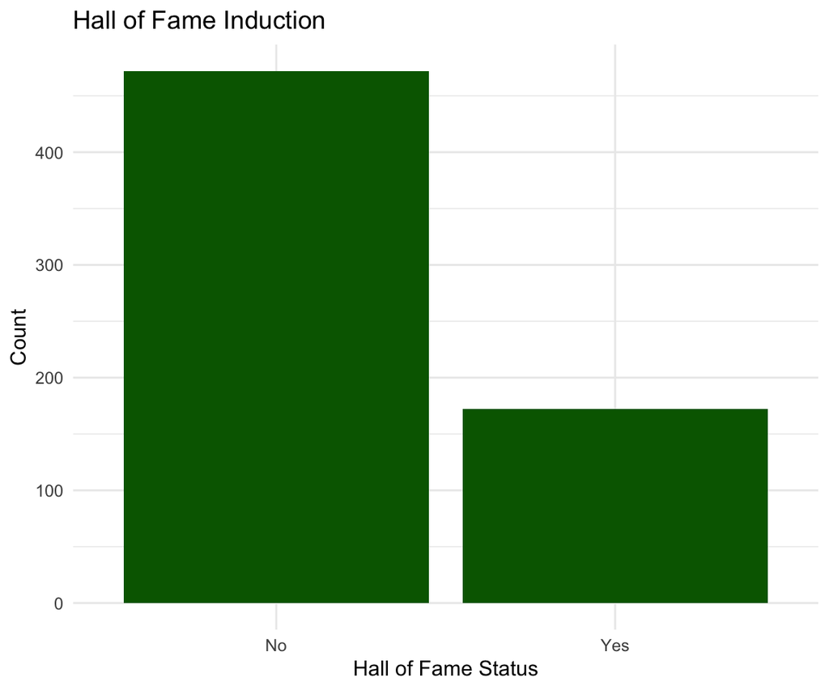

```r
# Bar Plot: Hall of Fame Status
ggplot(baseballHOF, aes(x = HoF)) +
  geom_bar(fill = "darkgreen") +
  labs(
    title = "Hall of Fame Induction",
    x = "Hall of Fame Status",
    y = "Count"
  ) +
  theme_minimal()
```

The frequency tables and bar charts show the distribution of player positions and Hall of Fame induction status. The dataset includes players from several positions, with infielders and outfielders representing the largest groups. The response variable includes both inducted and non-inducted players, providing data for building and evaluating the logistic regression model.

## Compare Players by Hall of Fame Status

This section compares the average values of the numeric variables for players who were inducted into the Hall of Fame and those who were not. These summaries help identify variables that may be useful for predicting Hall of Fame induction.

```r
library(dplyr)

comparison_summary <- baseballHOF %>%
  group_by(HoF) %>%
  summarise(
    across(
      where(is.numeric),
      ~ round(mean(.x, na.rm = TRUE), 2)
    )
  )

comparison_summary
```

```
## # A tibble: 2 × 20
##   HoF     Yrs   WAR  WAR7  JAWS  Jpos JAWSratio     G    AB     R     H    HR
##   <chr> <dbl> <dbl> <dbl> <dbl> <dbl>     <dbl> <dbl> <dbl> <dbl> <dbl> <dbl>
## 1 No     15.0  30.8  24.4  27.6  54.0      51.0 1671. 5885.  835. 1633.  154.
## 2 Yes    18.0  66.2  42    54.1  54.5      99.2 2172. 8025. 1330. 2420.  235.
## # ℹ 8 more variables: RBI <dbl>, SB <dbl>, BB <dbl>, BA <dbl>, OBP <dbl>,
## #   SLG <dbl>, OPS <dbl>, OPSadj <dbl>
```

The summary table shows that Hall of Fame players generally have higher average values for many career performance statistics, including WAR, JAWS, WAR7, home runs, RBIs, and on-base percentage. These differences suggest that these variables may help distinguish inducted players from non-inducted players.

## Boxplots by Hall of Fame Status

Boxplots compare the distribution of selected player statistics between inducted and non-inducted players. These plots provide a visual comparison of the two groups.

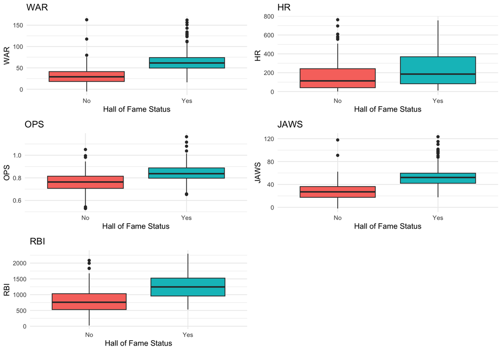

```r
library(ggplot2)
library(gridExtra)

selected_vars <- c("WAR", "HR", "OPS", "JAWS", "RBI")

boxplots <- lapply(selected_vars, function(var) {
  ggplot(baseballHOF,
         aes(x = HoF, y = .data[[var]], fill = HoF)) +
    geom_boxplot() +
    labs(
      title = var,
      x = "Hall of Fame Status",
      y = var
    ) +
    theme_minimal() +
    theme(legend.position = "none")
})

grid.arrange(grobs = boxplots, ncol = 2)
```

The boxplots show that inducted players generally have higher values for several career performance statistics than non-inducted players. Although the two groups overlap for some variables, many statistics show clear differences between the groups, supporting their use in the logistic regression model.

# Data Preparation

Before building the model, the dataset is checked for missing values and duplicate rows.

```r
# Check missing values
colSums(is.na(baseballHOF))
```

```
##      Name       HoF       Yrs       WAR      WAR7      JAWS      Jpos JAWSratio
##         0         0         0         0         0         0         0         0
##         G        AB         R         H        HR       RBI        SB        BB
##         0         0         0         0         0         0         0         0
##        BA       OBP       SLG       OPS    OPSadj  position
##         0         0         0         0         0         0
```

```r
# Check duplicate rows
sum(duplicated(baseballHOF))
```

```
## [1] 0
```

The results show that there are no missing values in any of the variables and no duplicate observations in the dataset.

# Model Development

Hall of Fame status has two possible outcomes: “Yes” and “No.” Therefore, logistic regression is used to estimate each player’s probability of being inducted into the Hall of Fame.

## Initial Logistic Regression Model

An initial logistic regression model was fitted using all available predictor variables. The model estimates the probability that a player will be inducted into the Hall of Fame based on career performance statistics.

```r
# Fit the model
library(dplyr)

baseballHOF$HOF <- factor(baseballHOF$HoF,
                          levels = c("No", "Yes"))
model_full <- glm(
  HOF ~ Yrs + WAR + WAR7 + JAWS + JAWSratio +
    G + AB + R + H + HR + RBI + SB + BB +
    BA + OBP + SLG + OPS + OPSadj + position,
  data = baseballHOF,
  family = binomial()
)
```

```r
# Predict Hall of Fame Status
predictions <- baseballHOF %>%
  mutate(
    Probability = predict(model_full, type = "response"),
    Predicted_HOF = ifelse(Probability >= 0.5, "Yes", "No")
  )

# Confusion matrix
conf_matrix <- table(
  Actual = predictions$HOF,
  Predicted = predictions$Predicted_HOF
)
conf_matrix
```

```
##       Predicted
## Actual  No Yes
##    No  446  26
##    Yes  45 127
```

```r
# Classification accuracy
accuracy <- sum(diag(conf_matrix)) / sum(conf_matrix)
misclassification <- 1 - accuracy

cat("Correct Classification:", round(accuracy * 100, 2), "%\n")
```

```
## Correct Classification: 88.98 %
```

```r
cat("Incorrect Classification:", round(misclassification * 100, 2), "%\n")
```

```
## Incorrect Classification: 11.02 %
```

The model correctly classified 446 players who were not inducted and 127 players who were inducted. It incorrectly classified 26 non-inducted players as inducted and 45 inducted players as non-inducted.

Overall, the model achieved an accuracy of **88.98%**, with an incorrect classification rate of **11.02%**. These results show that the full model fits the observed data well.

## Model Evaluation

The initial logistic regression model was evaluated using the likelihood ratio test and the Hosmer-Lemeshow goodness-of-fit test.

### Likelihood Ratio Test

The likelihood ratio test compares the full model with a model that contains no predictors. A small p-value indicates that the predictors improve the model.

```r
# Likelihood ratio test statistic
LRT <- model_full$null.deviance - model_full$deviance
df <- model_full$df.null - model_full$df.residual
p_value <- pchisq(LRT, df = df, lower.tail = FALSE)

LRT
```

```
## [1] 405.4397
```

```r
df
```

```
## [1] 25
```

```r
p_value
```

```
## [1] 2.388872e-70
```

The likelihood ratio test produced a p-value below 0.05. This shows that the full model provides a significantly better fit than a model with no predictors.

### Hosmer-Lemeshow Test

The Hosmer-Lemeshow test examines whether the predicted probabilities agree with the observed outcomes.

```r
library(ResourceSelection)
observed_HOF <- ifelse(baseballHOF$HoF == "Yes", 1, 0)
hoslem_result <- hoslem.test(
  observed_HOF,
  predictions$Probability,
  g = 10
)
hoslem_result
```

```
##
##  Hosmer and Lemeshow goodness of fit (GOF) test
##
## data:  observed_HOF, predictions$Probability
## X-squared = 6.2049, df = 8, p-value = 0.6243
```

The Hosmer-Lemeshow test produced a p-value of 0.6243 which is greater than 0.05. This indicates no significant difference between the observed and predicted outcomes, suggesting that the model fits the data adequately.

Overall, the model evaluation results indicate that the initial logistic regression model is appropriate for predicting Hall of Fame induction.

# Feature Selection

The initial model includes all available predictor variables. Feature selection is used to identify a smaller set of variables that provides a good model fit while reducing unnecessary complexity.

Backward, forward, and stepwise selection are compared using AIC. A lower AIC indicates a better balance between model fit and model complexity.

## Backward Selection

Backward selection begins with the full logistic regression model containing all predictor variables. Variables are then removed one at a time based on AIC. The process continues until removing additional variables no longer improves the model.

```r
backward_model <- step(
  model_full,
  direction = "backward",
  trace = FALSE
)

summary(backward_model)
```

```
##
## Call:
## glm(formula = HOF ~ Yrs + WAR7 + JAWS + JAWSratio + G + AB +
##     HR + RBI + BB + OBP, family = binomial(), data = baseballHOF)
##
## Coefficients:
##               Estimate Std. Error z value Pr(>|z|)
## (Intercept) -2.222e+01  4.010e+00  -5.541 3.02e-08 ***
## Yrs          2.047e-01  9.094e-02   2.251  0.02436 *
## WAR7         1.483e-01  6.846e-02   2.166  0.03031 *
## JAWS        -1.470e-01  7.939e-02  -1.852  0.06400 .
## JAWSratio    9.014e-02  2.957e-02   3.049  0.00230 **
## G           -3.759e-03  1.967e-03  -1.911  0.05599 .
## AB           1.087e-03  4.208e-04   2.583  0.00981 **
## HR          -7.024e-03  2.306e-03  -3.046  0.00232 **
## RBI          3.056e-03  1.127e-03   2.711  0.00670 **
## BB          -2.671e-03  1.063e-03  -2.513  0.01195 *
## OBP          3.368e+01  1.028e+01   3.276  0.00105 **
## ---
## Signif. codes:  0 '***' 0.001 '**' 0.01 '*' 0.05 '.' 0.1 ' ' 1
##
## (Dispersion parameter for binomial family taken to be 1)
##
##     Null deviance: 747.47  on 643  degrees of freedom
## Residual deviance: 354.38  on 633  degrees of freedom
## AIC: 376.38
##
## Number of Fisher Scoring iterations: 7
```

```r
formula(backward_model)
```

```
## HOF ~ Yrs + WAR7 + JAWS + JAWSratio + G + AB + HR + RBI + BB +
##     OBP
```

```r
AIC(backward_model)
```

```
## [1] 376.3792
```

## Forward Selection

Forward selection starts with a simple model and adds predictor variables one at a time. At each step, the variable that produces the greatest improvement in AIC is added. The process stops when no additional variable improves the model.

```r
null_model <- glm(
  HOF ~ 1,
  data = baseballHOF,
  family = binomial()
)

forward_model <- step(
  null_model,
  scope = list(
    lower = formula(null_model),
    upper = formula(model_full)
  ),
  direction = "forward",
  trace = FALSE
)

summary(forward_model)
```

```
##
## Call:
## glm(formula = HOF ~ JAWSratio + BA + OPS + RBI + HR + WAR + WAR7 +
##     Yrs + JAWS, family = binomial(), data = baseballHOF)
##
## Coefficients:
##               Estimate Std. Error z value Pr(>|z|)
## (Intercept) -19.879193   2.997968  -6.631 3.34e-11 ***
## JAWSratio     0.086648   0.026971   3.213 0.001315 **
## BA           38.393098  13.250761   2.897 0.003762 **
## OPS          -1.947771   4.511809  -0.432 0.665956
## RBI           0.003462   0.001036   3.342 0.000832 ***
## HR           -0.008202   0.002814  -2.914 0.003563 **
## WAR           2.657956   1.882837   1.412 0.158045
## WAR7          2.838855   1.886421   1.505 0.132352
## Yrs           0.106582   0.067321   1.583 0.113377
## JAWS         -5.481627   3.769120  -1.454 0.145849
## ---
## Signif. codes:  0 '***' 0.001 '**' 0.01 '*' 0.05 '.' 0.1 ' ' 1
##
## (Dispersion parameter for binomial family taken to be 1)
##
##     Null deviance: 747.47  on 643  degrees of freedom
## Residual deviance: 360.27  on 634  degrees of freedom
## AIC: 380.27
##
## Number of Fisher Scoring iterations: 6
```

```r
formula(forward_model)
```

```
## HOF ~ JAWSratio + BA + OPS + RBI + HR + WAR + WAR7 + Yrs + JAWS
```

```r
AIC(forward_model)
```

```
## [1] 380.2691
```

## Stepwise Selection

Stepwise selection combines forward and backward selection. Variables can be added or removed at each step based on the AIC criterion until the final model is obtained.

```r
stepwise_model <- step(
  model_full,
  direction = "both",
  trace = FALSE
)

summary(stepwise_model)
```

```
##
## Call:
## glm(formula = HOF ~ Yrs + WAR7 + JAWS + JAWSratio + G + AB +
##     HR + RBI + BB + OBP, family = binomial(), data = baseballHOF)
##
## Coefficients:
##               Estimate Std. Error z value Pr(>|z|)
## (Intercept) -2.222e+01  4.010e+00  -5.541 3.02e-08 ***
## Yrs          2.047e-01  9.094e-02   2.251  0.02436 *
## WAR7         1.483e-01  6.846e-02   2.166  0.03031 *
## JAWS        -1.470e-01  7.939e-02  -1.852  0.06400 .
## JAWSratio    9.014e-02  2.957e-02   3.049  0.00230 **
## G           -3.759e-03  1.967e-03  -1.911  0.05599 .
## AB           1.087e-03  4.208e-04   2.583  0.00981 **
## HR          -7.024e-03  2.306e-03  -3.046  0.00232 **
## RBI          3.056e-03  1.127e-03   2.711  0.00670 **
## BB          -2.671e-03  1.063e-03  -2.513  0.01195 *
## OBP          3.368e+01  1.028e+01   3.276  0.00105 **
## ---
## Signif. codes:  0 '***' 0.001 '**' 0.01 '*' 0.05 '.' 0.1 ' ' 1
##
## (Dispersion parameter for binomial family taken to be 1)
##
##     Null deviance: 747.47  on 643  degrees of freedom
## Residual deviance: 354.38  on 633  degrees of freedom
## AIC: 376.38
##
## Number of Fisher Scoring iterations: 7
```

```r
formula(stepwise_model)
```

```
## HOF ~ Yrs + WAR7 + JAWS + JAWSratio + G + AB + HR + RBI + BB +
##     OBP
```

```r
AIC(stepwise_model)
```

```
## [1] 376.3792
```

## Final Selected Model

The full, backward, forward, and stepwise models were compared using the AIC. The model with the lowest AIC was selected as the final model because it provided the best balance between model fit and model complexity.

```r
aic_comparison <- data.frame(
  Model = c(
    "Full Model",
    "Backward Selection",
    "Forward Selection",
    "Stepwise Selection"
  ),
  AIC = c(
    AIC(model_full),
    AIC(backward_model),
    AIC(forward_model),
    AIC(stepwise_model)
  )
)

aic_comparison
```

```
##                Model      AIC
## 1         Full Model 394.0300
## 2 Backward Selection 376.3792
## 3  Forward Selection 380.2691
## 4 Stepwise Selection 376.3792
```

```r
aic_comparison[
  which.min(aic_comparison$AIC),
]
```

```
##                Model      AIC
## 2 Backward Selection 376.3792
```

The backward and stepwise selection methods produced the same final model and the lowest AIC value of 376.38. The forward selection model had an AIC of 380.27, while the full model had the highest AIC of 394.03.

Because the backward and stepwise methods selected the same predictors and produced the same AIC, they represent the same final model. The backward-selected model was used for the remaining analysis.

# Final Model Evaluation

## Classification Performance

The final selected model was used to calculate each player’s predicted probability of Hall of Fame induction. Players with a predicted probability of at least 0.50 were classified as “Yes,” while the remaining players were classified as “No.” A confusion matrix and classification accuracy were then used to evaluate the model’s performance.

```r
final_model <- backward_model
selected_predictions <- baseballHOF %>%
  mutate(
    Probability = predict(
      final_model,
      newdata = baseballHOF,
      type = "response"
    ),
    Predicted_HOF = ifelse(
      Probability >= 0.5,
      "Yes",
      "No"
    )
  )

# Confusion matrix

selected_conf_matrix <- table(
  Actual = selected_predictions$HOF,
  Predicted = selected_predictions$Predicted_HOF
)
selected_conf_matrix
```

```
##       Predicted
## Actual  No Yes
##    No  449  23
##    Yes  46 126
```

```r
# Classification accuracy
selected_accuracy <- sum(diag(selected_conf_matrix)) /
  sum(selected_conf_matrix)

selected_misclassification <- 1 - selected_accuracy

cat(
  "Correct Classification:",
  round(selected_accuracy * 100, 2),
  "%\n"
)
```

```
## Correct Classification: 89.29 %
```

```r
cat(
  "Incorrect Classification:",
  round(selected_misclassification * 100, 2),
  "%\n"
)
```

```
## Incorrect Classification: 10.71 %
```

The final selected model correctly classified 449 players who were not inducted into the Hall of Fame and 126 players who were inducted. It incorrectly classified 23 non-inducted players as inducted and 46 inducted players as non-inducted.

Overall, the selected model achieved a classification accuracy of **89.29%**, with an incorrect classification rate of **10.71%**. This accuracy is slightly higher than that of the full model (88.98%), indicating that the selected model provides slightly better predictive performance while using fewer predictor variables. These results suggest that feature selection improved the model by reducing complexity without sacrificing accuracy.

## Likelihood ratio and Hosmer-Lemeshow tests

The final selected model was evaluated using the likelihood ratio test and the Hosmer-Lemeshow goodness-of-fit test.

```r
#Likelihood Ratio Test
LRT_selected <- final_model$null.deviance - final_model$deviance
df_selected <- final_model$df.null - final_model$df.residual
p_value_selected <- pchisq(
  LRT_selected,
  df = df_selected,
  lower.tail = FALSE
)
LRT_selected
```

```
## [1] 393.0905
```

```r
df_selected
```

```
## [1] 10
```

```r
p_value_selected
```

```
## [1] 2.779744e-78
```

```r
# Hosmer-Lemeshow Test
library(ResourceSelection)

observed_HOF <- ifelse(
  baseballHOF$HOF == "Yes",
  1,
  0
)
selected_probabilities <- predict(
  final_model,
  type = "response"
)
hoslem_selected <- hoslem.test(
  observed_HOF,
  selected_probabilities,
  g = 10
)
hoslem_selected
```

```
##
##  Hosmer and Lemeshow goodness of fit (GOF) test
##
## data:  observed_HOF, selected_probabilities
## X-squared = 5.7014, df = 8, p-value = 0.6806
```

The likelihood ratio test was statistically significant (p < 0.05), indicating that the selected model provides a significantly better fit than the null model.

The Hosmer-Lemeshow test was not statistically significant (p-value=0.6806 > 0.05), indicating no evidence of poor fit. Therefore, the selected model fits the observed data adequately.

Overall, the selected model demonstrates good model fit.

# Prediction

The final selected logistic regression model was used to predict the probability of Hall of Fame induction for the players on the 2026 Hall of Fame ballot. Players with a predicted probability of at least 0.50 were classified as likely to be inducted into the Hall of Fame.

```r
baseballHOF2026 <- read.csv("~/Desktop/courses/Projects/project1/baseballHOF2026.csv")
predictions <- predict(
  final_model,
  newdata = baseballHOF2026,
  type = "response"
)

predicted_class <- ifelse(predictions >= 0.5, "Yes", "No")

baseballHOF2026$Probability <- predictions
baseballHOF2026$Predicted_HOF <- predicted_class

baseballHOF2026 %>%
  mutate(Probability = round(Probability, 3)) %>%
  select(Name, Probability, Predicted_HOF)
```

```
##                 Name Probability Predicted_HOF
## 1         Ryan Braun       0.360            No
## 2        Alex Gordon       0.040            No
## 3      Shin-Soo Choo       0.075            No
## 4  Edwin Encarnacion       0.024            No
## 5     Howie Kendrick       0.052            No
## 6      Nick Markakis       0.065            No
## 7       Hunter Pence       0.030            No
## 8          Matt Kemp       0.018            No
## 9       Jason Kipnis       0.003            No
## 10     Daniel Murphy       0.009            No
## 11      Matt Wieters       0.002            No
## 12       Chris Davis       0.001            No
```

The predicted probabilities for all 12 players were below the 0.50 classification threshold. Therefore, the model predicted that none of the players on the 2026 ballot would be inducted into the Hall of Fame.

# Conclusion

This project developed a logistic regression model to predict Major League Baseball Hall of Fame induction using players’ career performance statistics. The analysis included exploratory data analysis, data preparation, model development, feature selection, model evaluation, and prediction.

Feature selection was performed using backward, forward, and stepwise selection. Both the backward and stepwise methods produced the same final model with the lowest AIC, indicating the best balance between model fit and model complexity. The selected model achieved a classification accuracy of **89.29%**, which was slightly higher than the accuracy of the full model (**88.98%**). In addition, the likelihood ratio test showed that the model was statistically significant, and the Hosmer-Lemeshow test indicated a good fit to the observed data.

The final model was then applied to the 2026 Hall of Fame dataset to estimate each player’s probability of induction. Based on a classification threshold of 0.50, none of the players on the 2026 ballot were predicted to be inducted into the Hall of Fame.

Overall, the results demonstrate that logistic regression is an effective method for modeling Hall of Fame induction and that feature selection can improve model simplicity while maintaining strong predictive performance.